# Data Wrangling

## Agenda

- Joins
- Binding
- Set operators
- Readings: R4DS Chapters 13
- Other sources:
  - [SQL vs dplyr](https://blog.exploratory.io/why-sql-is-not-for-analysis-but-dplyr-is-5e180fef6aa7)
  - [dplyr for databases](https://blog.exploratory.io/using-dplyr-to-query-databases-directly-instead-of-using-sql-fed43f059ed6)

## Population size and electoral votes

Suppose we want to explore the relationship between population size for US states and electoral votes. We have the population size in this table:

```r
library(tidyverse)
library(dslabs)
data(murders)
head(murders)
##        state abb region population total
## 1    Alabama  AL  South    4779736   135
## 2     Alaska  AK   West     710231    19
## 3    Arizona  AZ   West    6392017   232
## 4   Arkansas  AR  South    2915918    93
## 5 California  CA   West   37253956  1257
## 6   Colorado  CO   West    5029196    65
```

## Electoral votes

and electoral votes in this one:

```r
data(polls_us_election_2016)
head(results_us_election_2016)
##          state electoral_votes clinton trump others
## 1   California              55    61.7  31.6    6.7
## 2        Texas              38    43.2  52.2    4.5
## 3      Florida              29    47.8  49.0    3.2
## 4     New York              29    59.0  36.5    4.5
## 5     Illinois              20    55.8  38.8    5.4
## 6 Pennsylvania              20    47.9  48.6    3.6
```

## Goal

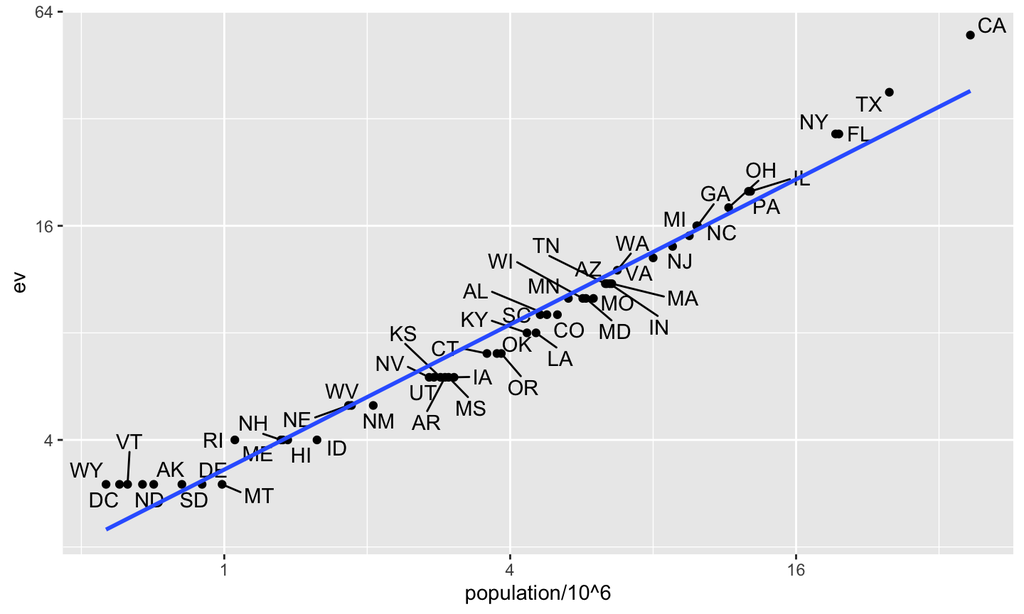

## cbind?

Just concatenating these two tables together will not work since the order of the states is not the same.

```r
identical(results_us_election_2016$state, murders$state)
## [1] FALSE
```

## Joining in dplyr

Joining in `dplyr` is pretty straightforward, and similar to SQL

- Verbs are similar between the two approaches
- Common tasks in a data analysis are easier in `dplyr`
- Uncommon tasks are more challenging in `dplyr`

## Joins

- It is not always the case that each row in one table has a matching row in the other
- Join options:
  - Left Join (`left_join`)
  - Right Join (’right_join`)
  - Inner Join (`inner_join`)
  - Full Join (’full_join`)
  - Semi Join (`semi_join`)
  - Anti Join (`anti_join`)

## Murders example

```r
tab_1 <- slice(murders, 1:6) %>% select(state, population)
tab_1
##        state population
## 1    Alabama    4779736
## 2     Alaska     710231
## 3    Arizona    6392017
## 4   Arkansas    2915918
## 5 California   37253956
## 6   Colorado    5029196
```

## Murders example

```r
tab_2 <- results_us_election_2016 %>%
  filter(state%in%c("Alabama", "Alaska", "Arizona",
                    "California", "Connecticut", "Delaware")) %>%
  select(state, electoral_votes) %>% rename(ev = electoral_votes)
tab_2
##         state ev
## 1  California 55
## 2     Arizona 11
## 3     Alabama  9
## 4 Connecticut  7
## 5      Alaska  3
## 6    Delaware  3
```

## Left join

Starting with `tab_1`, add `ev` data for whichever states are available in `tab_2` (missing values encoded in `ev`)

```r
#left_join(tab_1, tab_2, by = "state")
tab_1 %>% left_join(tab_2, by = "state")
##        state population ev
## 1    Alabama    4779736  9
## 2     Alaska     710231  3
## 3    Arizona    6392017 11
## 4   Arkansas    2915918 NA
## 5 California   37253956 55
## 6   Colorado    5029196 NA
```

## Right join

Conceptually, `tab_2` is our starting table, and we add population data to it (missing values in `population`)

```r
tab_1 %>% right_join(tab_2, by = "state")
##         state population ev
## 1  California   37253956 55
## 2     Arizona    6392017 11
## 3     Alabama    4779736  9
## 4 Connecticut         NA  7
## 5      Alaska     710231  3
## 6    Delaware         NA  3
```

## Inner join

Conceptually, the intersection (no missing values)

```r
inner_join(tab_1, tab_2, by = "state")
##        state population ev
## 1    Alabama    4779736  9
## 2     Alaska     710231  3
## 3    Arizona    6392017 11
## 4 California   37253956 55
```

## Full join

Conceptually the union (missing values in `population` AND `ev`)

```r
full_join(tab_1, tab_2, by = "state")
##         state population ev
## 1     Alabama    4779736  9
## 2      Alaska     710231  3
## 3     Arizona    6392017 11
## 4    Arkansas    2915918 NA
## 5  California   37253956 55
## 6    Colorado    5029196 NA
## 7 Connecticut         NA  7
## 8    Delaware         NA  3
```

## Semi join

Keep parts of the first table for which information exists in the second

```r
semi_join(tab_1, tab_2, by = "state")
##        state population
## 1    Alabama    4779736
## 2     Alaska     710231
## 3    Arizona    6392017
## 4 California   37253956
```

## Anti join

The opposite of `semi_join`

```r
anti_join(tab_1, tab_2, by = "state")
##      state population
## 1 Arkansas    2915918
## 2 Colorado    5029196
```

## Back to the goal

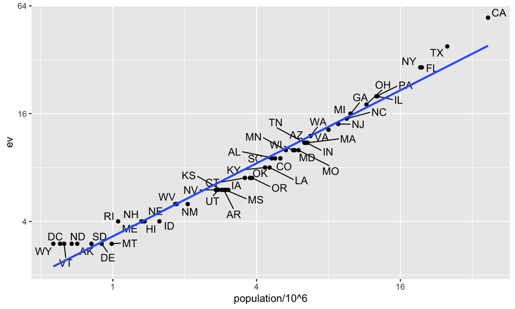

```r
library(ggrepel)
tab <- left_join(murders, results_us_election_2016, by = "state") %>%
  select(-others) %>% rename(ev = electoral_votes)
tab %>% ggplot(aes(population/10^6, ev, label = abb)) +
  geom_point() +
  geom_text_repel() +
  scale_x_continuous(trans = "log2") +
  scale_y_continuous(trans = "log2") +
  geom_smooth(method = "lm", se = FALSE)
```

## Binding columns

Rather than trying to match by a variable, we might want to simply combine datasets

```r
tab_1 <- tab[, 1:3]
tab_2 <- tab[, 4:6]
tab_3 <- tab[, 7:8]
new_tab <- bind_cols(tab_1, tab_2, tab_3)
head(new_tab)
##        state abb region population total ev clinton trump
## 1    Alabama  AL  South    4779736   135  9    34.4  62.1
## 2     Alaska  AK   West     710231    19  3    36.6  51.3
## 3    Arizona  AZ   West    6392017   232 11    45.1  48.7
## 4   Arkansas  AR  South    2915918    93  6    33.7  60.6
## 5 California  CA   West   37253956  1257 55    61.7  31.6
## 6   Colorado  CO   West    5029196    65  9    48.2  43.3
# What type of object is new_tab?
```

## Binding rows

```r
tab_1 <- tab[1:2,]
tab_2 <- tab[3:4,]
bind_rows(tab_1, tab_2)
##      state abb region population total ev clinton trump
## 1  Alabama  AL  South    4779736   135  9    34.4  62.1
## 2   Alaska  AK   West     710231    19  3    36.6  51.3
## 3  Arizona  AZ   West    6392017   232 11    45.1  48.7
## 4 Arkansas  AR  South    2915918    93  6    33.7  60.6
```

## Set operators

- `intersect`
- `union`
- `setdiff`
- `setequal`

## Intersect

```r
tab_1 <- tab[1:5,]
tab_2 <- tab[3:7,]
dplyr::intersect(tab_1, tab_2)
##        state abb region population total ev clinton trump
## 1    Arizona  AZ   West    6392017   232 11    45.1  48.7
## 2   Arkansas  AR  South    2915918    93  6    33.7  60.6
## 3 California  CA   West   37253956  1257 55    61.7  31.6
```

## Union

```r
tab_1 <- tab[1:5,]
tab_2 <- tab[3:7,]
dplyr::union(tab_1, tab_2)
##         state abb    region population total ev clinton trump
## 1     Alabama  AL     South    4779736   135  9    34.4  62.1
## 2      Alaska  AK      West     710231    19  3    36.6  51.3
## 3     Arizona  AZ      West    6392017   232 11    45.1  48.7
## 4    Arkansas  AR     South    2915918    93  6    33.7  60.6
## 5  California  CA      West   37253956  1257 55    61.7  31.6
## 6    Colorado  CO      West    5029196    65  9    48.2  43.3
## 7 Connecticut  CT Northeast    3574097    97  7    54.6  40.9
```

## Setdiff

```r
tab_1 <- tab[1:5,]
tab_2 <- tab[3:7,]
dplyr::setdiff(tab_1, tab_2)
##     state abb region population total ev clinton trump
## 1 Alabama  AL  South    4779736   135  9    34.4  62.1
## 2  Alaska  AK   West     710231    19  3    36.6  51.3
```

## Setdiff

```r
tab_1 <- tab[1:5,]
tab_2 <- tab[3:7,]
dplyr::setdiff(tab_2, tab_1)
##         state abb    region population total ev clinton trump
## 1    Colorado  CO      West    5029196    65  9    48.2  43.3
## 2 Connecticut  CT Northeast    3574097    97  7    54.6  40.9
```

## Setequal

```r
dplyr::setequal(tab_1, tab_2)
## [1] FALSE
```

## Comparisons

| R jargon | Database jargon | dplyr jargon |
| --- | --- | --- |
| dataframe | table | either! |
| collection of data frames | database | either! |
| conditional indexing | `SELECT`, `FROM`, `WHERE`, `HAVING` | `filter()` |
| `d*ply()` | `GROUP BY` | `group_by` |
| `order()` | `ORDER BY` | `arrange` |
| `base` functions | `SELECT` functions | `summarize` |
| `base` functions | `SELECT` functions | `mutate` |

## Databases

The `dbplyr` library provides functionality for connecting to databases and using dplyr (rather than SQL variants)

- Second reference link compares `dbplyr` and `dplyr` to SQL commands
- Take a look at “Exploratory” - the software referenced in that link